# Analisi del rateo dei suicidi nel mondo

5/1/2023

## Introduzione

Questa presentazione andrà ad analizzare quanto il problema dei suicidi è risultato numericamente impattante in diversi contesti e condizioni nell’arco temporale compreso tra il **1985** e il **2016**.

Tutte le informazioni utilizzate all’interno di questa presentazione sono state prese dal dataset https://www.kaggle.com/datasets/dzikrifaizziyan/suicide-rates-overview-1985-to-2016.

## Primo sguardo ai dati

Prima di iniziare è utile dare una prima occhiata ai dati, per capire il tipo di informazioni che vi possiamo ricavare

```
## # A tibble: 27,820 x 13
##       id country        year sex   age   suici~1 popul~2 suici~3 count~4 HDI f~5
##    <int> <chr>         <dbl> <chr> <chr>   <dbl>   <dbl>   <dbl> <chr>     <dbl>
##  1 26002 Turkmenistan   2010 fema~ 15-2~      22  547882    4.02 Turkme~   0.666
##  2 21077 Russia         2000 fema~ 25-3~    1027 9648389   10.6  Russia~  NA
##  3 20333 Republic of ~  1993 fema~ 25-3~     322 4131600    7.79 Republ~  NA
##  4 13721 Japan          2014 fema~ 25-3~     814 6734000   12.1  Japan2~   0.891
##  5  6066 Costa Rica     1989 fema~ 05-1~       2  334000    0.6  Costa ~  NA
##  6 14326 Kuwait         2002 male  25-3~      11  388020    2.83 Kuwait~  NA
##  7    33 Albania        1989 fema~ 55-7~       1  149600    0.67 Albani~  NA
##  8  6911 Cuba           2015 male  25-3~      82  773518   10.6  Cuba20~  NA
##  9 17576 New Zealand    1995 fema~ 35-5~      36  488300    7.37 New Ze~   0.855
## 10 22500 Singapore      1993 male  35-5~      56  420500   13.3  Singap~  NA
## # ... with 27,810 more rows, 3 more variables: gdp_for_year <dbl>,
## #   gdp_per_capita <dbl>, generation <chr>, and abbreviated variable names
## #   1: suicides_no, 2: population, 3: suicides_in_100k_pop, 4: `country-year`,
## #   5: `HDI for year`
```

I dati di maggiore interesse della tabella precedente sono:

- La nazione
- Il sesso
- L’età
- Il numero dei suicidi
- La quantità di popolazione
- Il GDP pro capite (in italiano PIL pro capite)
- Il rateo dei suicidi ogni 100 000 abitanti (ottenuto tramite la relazione tra il numero dei suicidi e la quantità di popolazione di riferimento)

## Nazioni

Il primo aspetto interessante da analizzare è quello di comprendere quali siano le nazioni in cui i suicidi risultano essere un problema più o meno presente

La tabella precedentemente mostrata possiede un dato che può essere particolarmente significativo al fine di rispondere a questa domanda, ossia il numero di suicidi ogni 100 000 abitanti.

E’ dunque possibile fare una classifica delle nazioni sulla base di questo dato.

In questo caso in particolare andremo a prendere le 10 nazioni più affette dal problema e le 10 nazioni meno affette dal problema

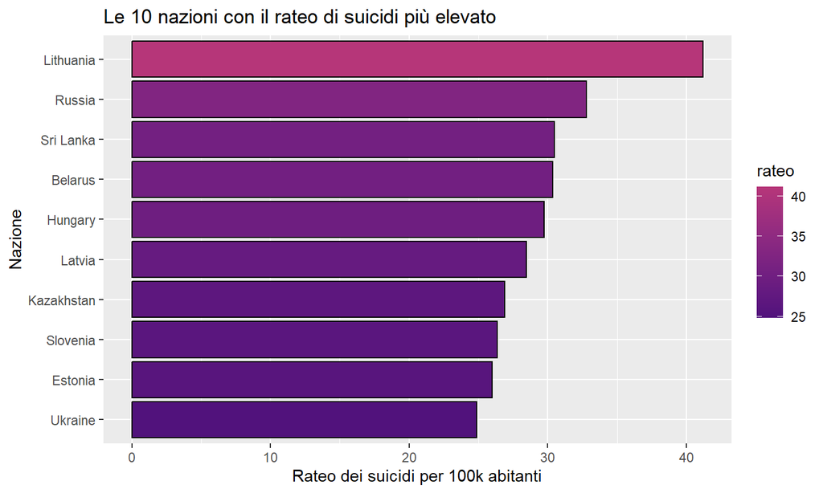

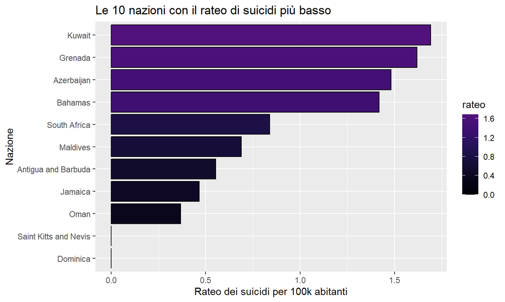

## Sesso

Quanto il sesso incide all’interno del problema dei suicidi in italia?

Il comportamento del caso italiano corrisponde al comportamento generale nel mondo?

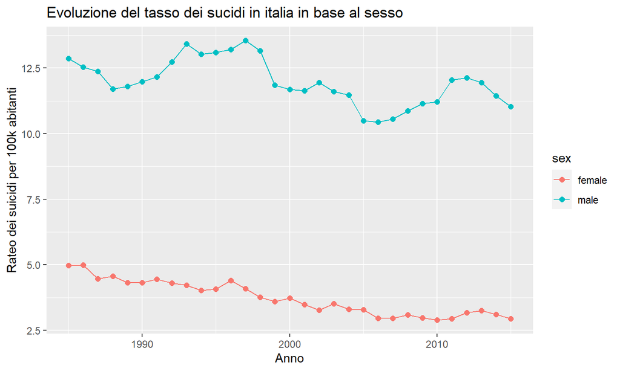

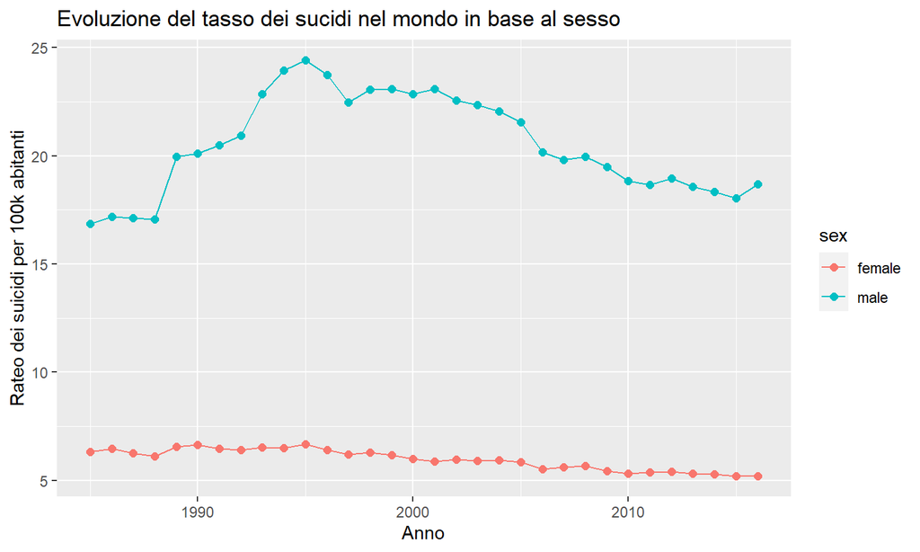

Sia prendendo il solo caso italiano che il caso globale è evidente che essere uomo porta con sè una maggiore probabilità di ricorrere al suicidio lungo la propria vita.

Nel caso globale si può notare addirittura una differenza maggiore e particolarmente importante lungo il periodo tra il 1990 e il 2005.

In generale è possibile affermare che statisticamente almeno 3/4 dei suicidi avvengono da parte degli uomini.

Ed una differenza così sostanziale va tenuta in considerazione nelle prossime parti per verificare se tra i due sessi vi sono delle ulteriori differenze.

## Età

Allo stesso modo, l’età è un elemento incisivo nel numero dei sucidi?

Diverse fasce d’età tendono a ricorrere al suicidio con probabilità diverse?

E’ possibile osservare una qualche forma di relazione?

Questo comportamento vale in generale, solo per gli uomini o solo per le donne?

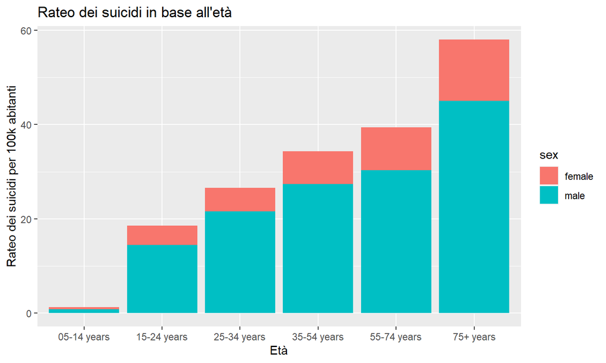

Risulta evidente che alle domande precedenti la risposta è che al crescere dell’età aumenta considerevolmente la probabilità di ricorrere al suicidio, e questo vale sia per gli uomini che per le donne anche se in entità e misure diverse.

## PIL pro-capite e quantità di popolazione

Sono il PIL pro-capite e la quantità di popolazione di una nazione influenti nel determinare quanto statisticamente le persone ricorrono al suicidio?

Sono questi dati impattanti allo stesso modo per gli uomini e per le donne?

Grafico di correlazione per gli uomini:

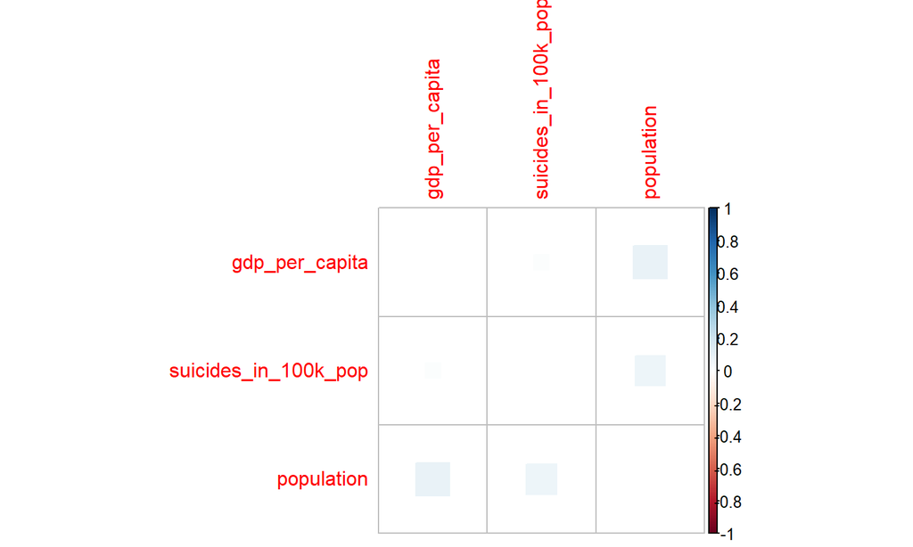

Grafico di correlazione per le donne:

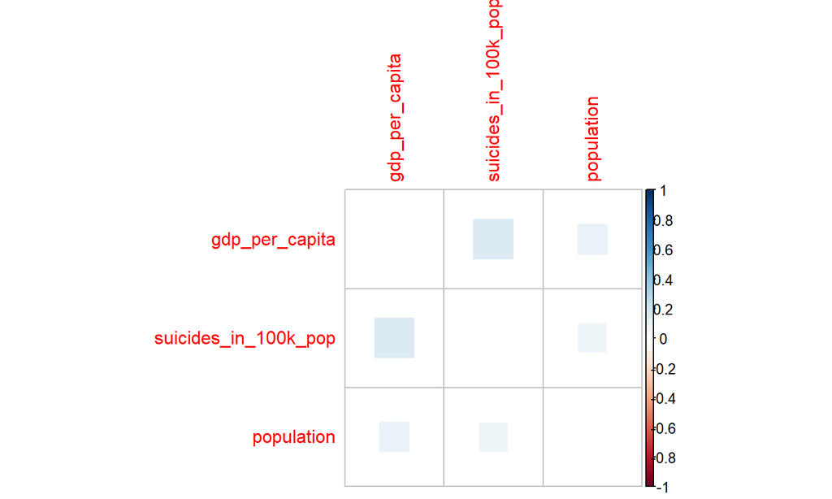

Come si evince dai grafici di correlazione, nessuno dei dati in questione sembra essere strettamente legato al numero dei suicidi, cioè all’aumentare del PIL pro-capite o della popolazione non siamo in grado di affermare che aumenterà o diminuirà sicuramente il rateo dei suicidi.

Per avere anche una visione di tipo differente è interessante osservare il seguente grafico a punti:

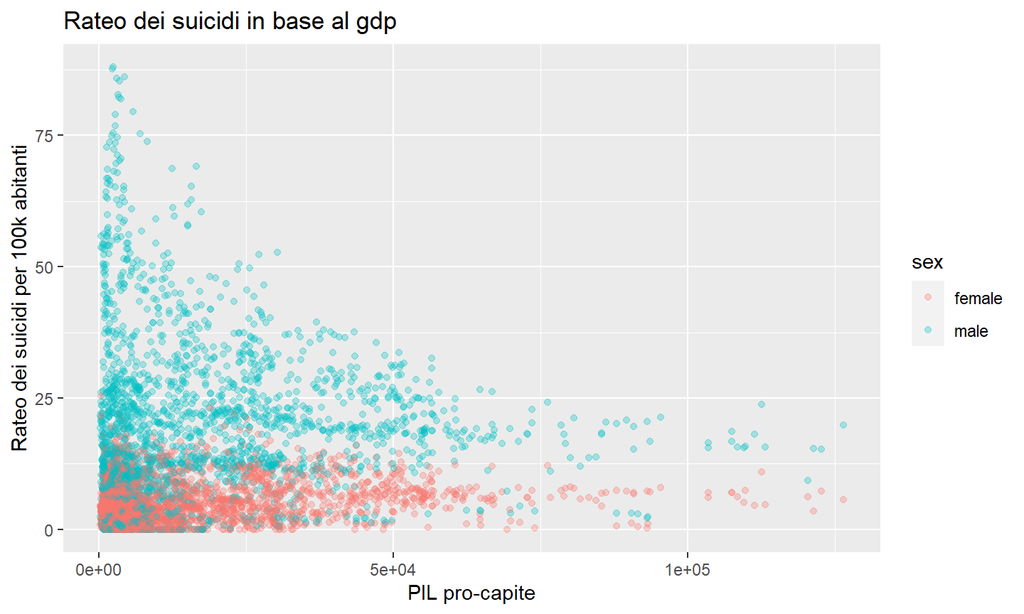

Questo grafico ci conferma solo parzialmente quanto detto dal grafico di correlazione, infatti possiamo vedere che non si è formata alcuna forma riconducibile facilmente a una retta tra i due valori che ne indichi una correlazione lineare.

Dall’altro lato però ci consente di osservare che i due dati non sono completamente slegati e che i paesi con il rateo dei suicidi più alto in assoluto sono anche contemporaneamente i paesi più poveri, e che la nuvola dei punti tende ad essere in discesa sulla parte superiore.

Nonostante questo esistono altrettanti paesi poveri i quali non hanno subito in maniera così pesante il problema.

## Mappa

In conclusione riporto una mappa complessiva per gli uomini e una per le donne della situazione globale del rateo dei suici, le quali consentono di osservare come le questioni culturali potrebbero essere notevolmente determinanti in questo ambito.

Regioni diverse del mondo infatti sembrano avere delle relazioni nel numero dei suicidi nei confronti delle regioni vicine con culture simili o storicamente legate.

Inoltre è possibile osservare come questi elementi culturali colpiscano in modo leggermente diverso uomini e donne

Le due mappe riportano la situazione al **1995** data in cui il problema risultava più impattante (da grafico sul sesso).

Mappa per gli uomini:

[interactive chart not shown]

Mappa per le donne:

[interactive chart not shown]

## Considerazioni finali

Come è stato possibile vedere dagli utlimi grafici in realtà molte delle nazioni del mondo non condividono i propri dati.

Queste sono tipicamente nazioni del terzo mondo e nazioni in cui le condizioni politiche non consentono di raccogliere i dati o non risulta conveniente per i Paesi stessi condividerli.

Per le nazioni del terzo mondo che invece hanno fornito i propri dati, questi risultano intuitivamente un po’ strani ed è difficile affermare con certezza che questi ultimi siano stati raccolti e trattati con correttezza.

In ogni caso il fatto che manchi una grossa porzione del mondo a questo set di dati potrebbe portare a una rivalutazione di alcuni criteri come per esempio il collegamento tra pil pro-capite e numero dei suicidi.

Quello che si è fatto in questa relazione è analizzare i dati attualmente in nostro possesso e rispondere attraverso essi a delle domande, ma nelle risposte date è importante tenere in conto i limiti appena citati.